# HaymanFire_Assignment2

Alex Siggers

03 February, 2022

1. What is the correlation between NDVI and NDMI?

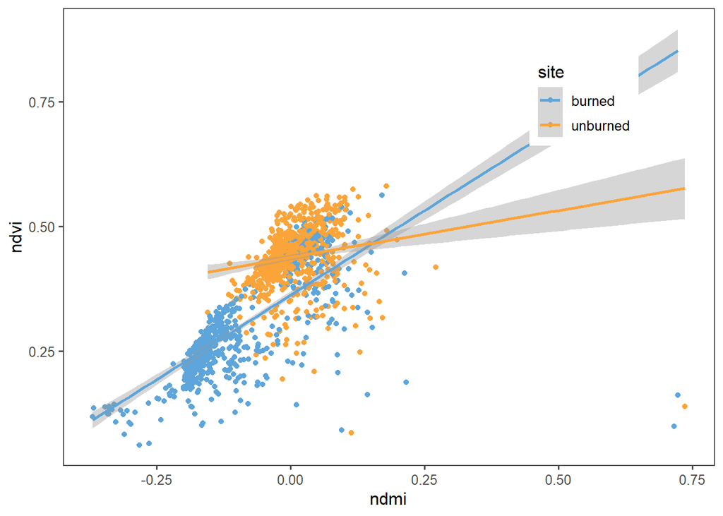

*There appears to be a consistent positive correlation between NDMI (vegetation water content) and NDVI (vegetative cover) in the summer months at all sites on average. This correlation is stronger in the burned sites, which may be driven largely by post-fire succession.

2. What is the correlation between average NDSI (normalized snow index) for January - April and average NDVI for June-August?

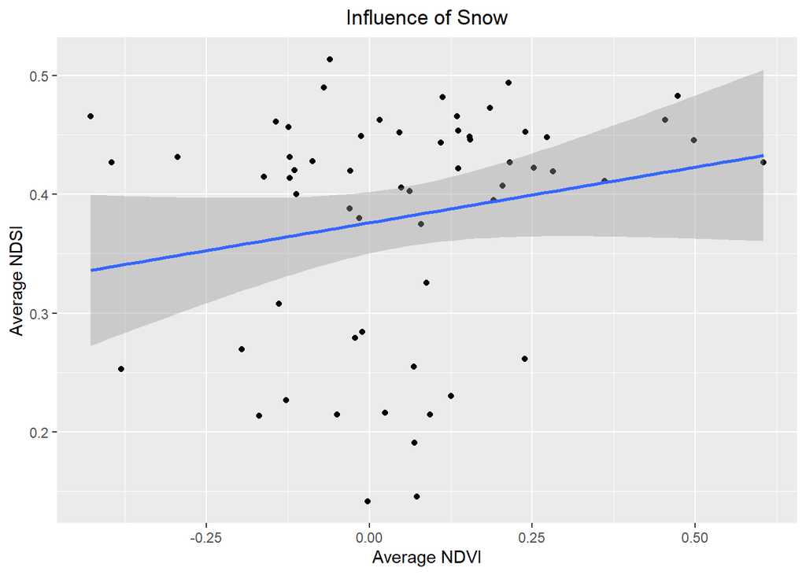

*After taking averages and fitting to a linear model, it appears that there is a slightly positive correlation. This leads me to believe that increased winter snowfall may encourage vegetative growth in the concurrent summer months.

3. How is the snow effect from question 2 different between pre- and post-burn and burned and unburned?

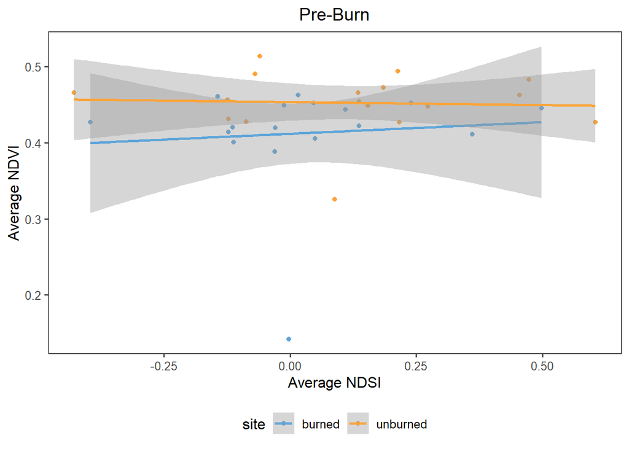

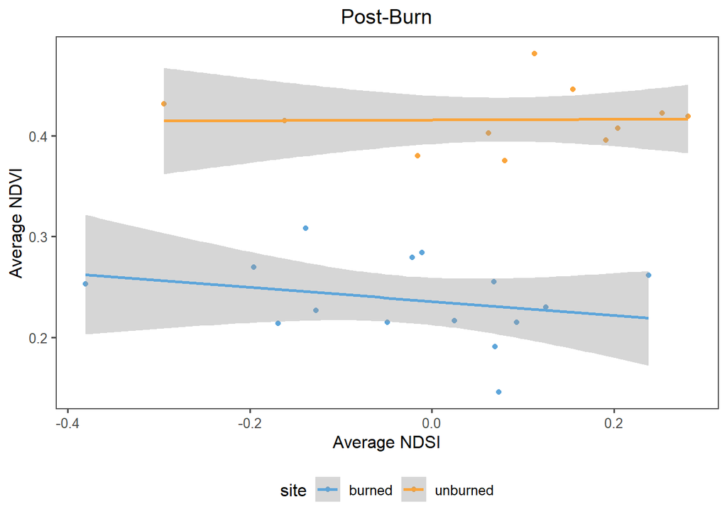

4. What month is the greenest month on average?

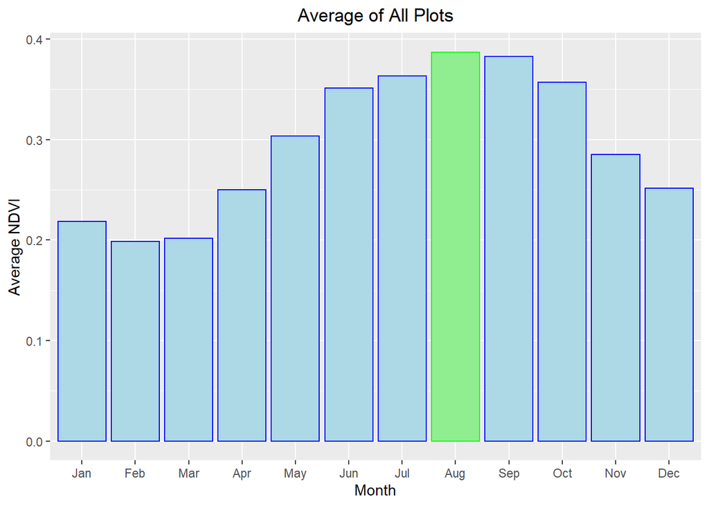

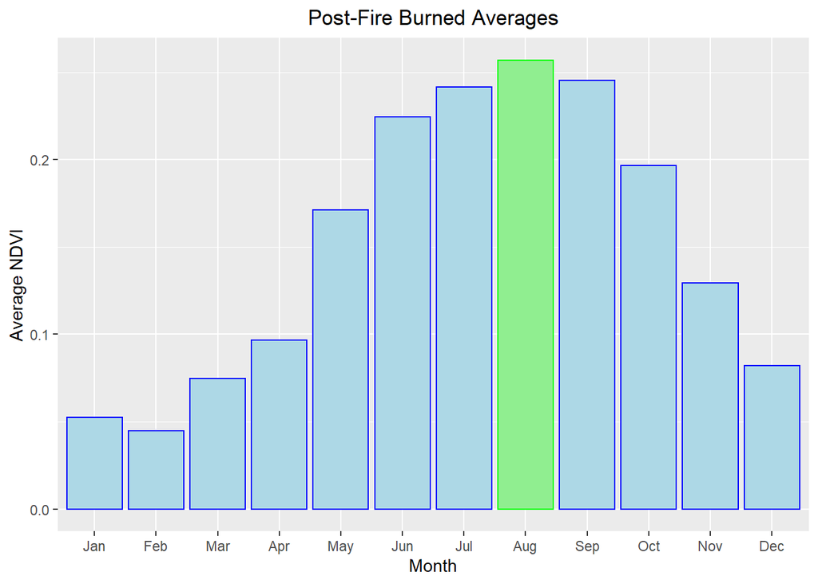

*August is the greenest month across all plots and remains so in burned plots following the fire.

5. What month is the snowiest on average?

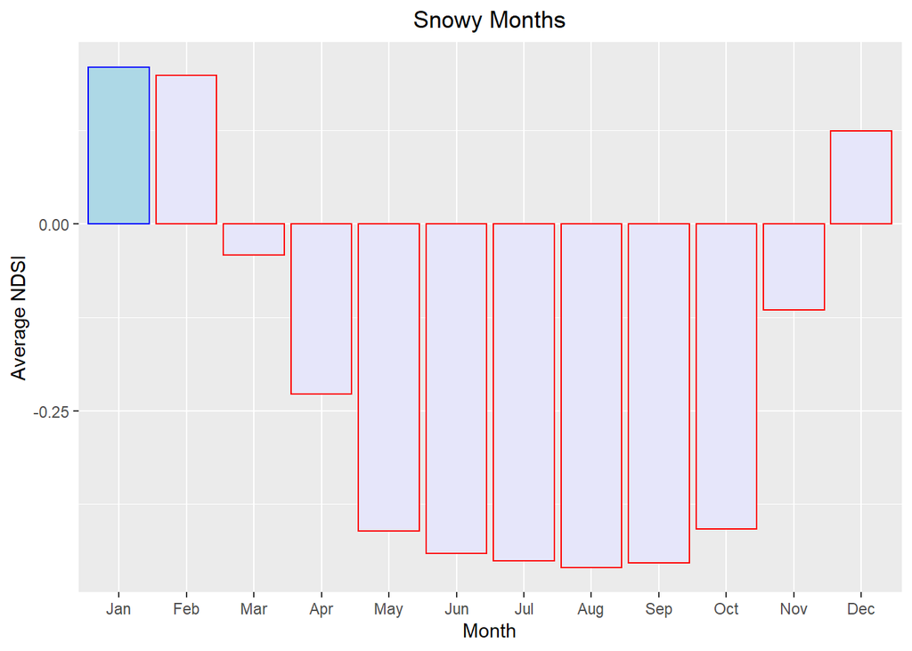

*January is the snowiest month on average across all plots (as outlined in blue).